# p8105_hw6_jl5295

Jana Lee

11/22/2019

## Problem 1:

In this problem, you will analyze data gathered to understand the effects of several variables on a child’s birthweight. This dataset, available here, consists of roughly 4000 children and includes the following variables:

babysex: baby’s sex (male = 1, female = 2) bhead: baby’s head circumference at birth (centimeters) blength: baby’s length at birth (centimeteres) bwt: baby’s birth weight (grams) delwt: mother’s weight at delivery (pounds) fincome: family monthly income (in hundreds, rounded) frace: father’s race (1 = White, 2 = Black, 3 = Asian, 4 = Puerto Rican, 8 = Other, 9 = Unknown) gaweeks: gestational age in weeks malform: presence of malformations that could affect weight (0 = absent, 1 = present) menarche: mother’s age at menarche (years) mheigth: mother’s height (inches) momage: mother’s age at delivery (years) mrace: mother’s race (1 = White, 2 = Black, 3 = Asian, 4 = Puerto Rican, 8 = Other) parity: number of live births prior to this pregnancy pnumlbw: previous number of low birth weight babies pnumgsa: number of prior small for gestational age babies ppbmi: mother’s pre-pregnancy BMI ppwt: mother’s pre-pregnancy weight (pounds) smoken: average number of cigarettes smoked per day during pregnancy wtgain: mother’s weight gain during pregnancy (pounds)

### Loading and Tidying the Dataset

```r
birthweight =
  read.csv("data/birthweight.csv") %>%
  janitor::clean_names() %>%
  mutate(
    babysex = factor(babysex, levels = c(1, 2), labels = c("male", "female")),
    frace = factor(frace, levels = c(1, 2, 3, 4, 8, 9), labels = c("white", "black", "asian", "puerto rican", "other", "unknown")),
    mrace = factor(mrace, levels = c(1, 2, 3, 4, 8, 9), labels = c("white", "black", "asian", "puerto rican", "other", "unknown")),
    malform = factor(malform, levels = c(0, 1), labels = c("absent", "present"))
  )
```

**Comment:** From loading and tidying the data, we confirm that all variables have the appropriate structure (factor, numeric, etc.).

### Propose a regression model for birthweight

Propose a regression model for birthweight. This model may be based on a hypothesized structure for the factors that underly birthweight, on a data-driven model-building process, or a combination of the two. Describe your modeling process and show a plot of model residuals against fitted values – use add_predictions and add_residuals in making this plot.

```r
birthweight_base_model =
  lm(bwt ~ babysex + blength + gaweeks + mheight + smoken, data = birthweight)
```

Plot model residuals for birthweight_base_model against the fitted values:

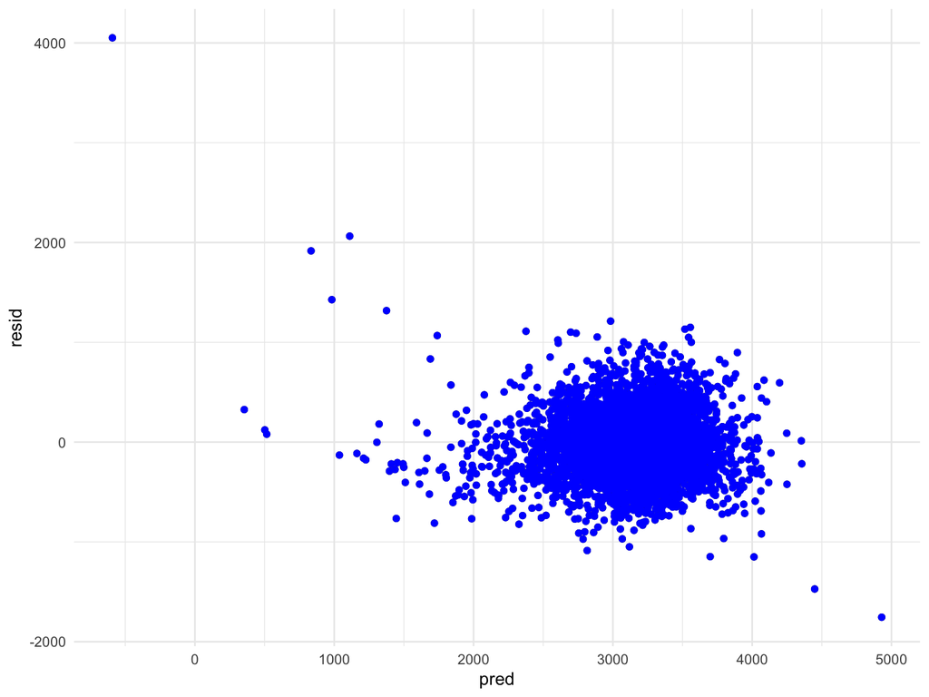

```r
birthweight_residuals_base = modelr::add_residuals(birthweight, birthweight_base_model)
birthweight_residuals_base = modelr::add_predictions(birthweight_residuals_base, birthweight_base_model)

birthweight_residuals_base %>%
  ggplot(aes(x = pred, y = resid)) +
  geom_point() +
  geom_point(color = "blue")
```

## Compare this model to two others:

First model: One using length at birth and gestational age as predictors (main effects only)

```r
birthweight_1_model =
  lm(bwt ~ blength + gaweeks, data = birthweight)
```

Second model: One using head circumference, length, sex, and all interactions (including the three-way interaction) between these

```r
birthweight_2_model =
  lm(bwt ~ bhead + blength + babysex + bhead*blength + bhead*babysex + bhead*babysex + bhead*blength*babysex, data = birthweight)
```

Make this comparison in terms of the cross-validated prediction error; use crossv_mc and functions in purrr as appropriate.

Note that although we expect your model to be reasonable, model building itself is not a main idea of the course and we don’t necessarily expect your model to be “optimal”.

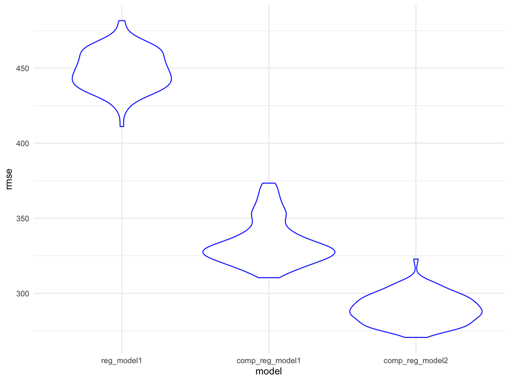

```r
crossval_bwt = crossv_mc(birthweight, 100)
crossval_bwt =
  crossval_bwt %>%
  mutate(reg_model1 = map(train, ~lm(bwt ~ babysex + gaweeks + momage + mheight + parity + ppbmi + pnumlbw + smoken, data = .x)),
  comp_reg_model1 = map(train, ~lm(bwt ~ blength + gaweeks, data = .x)),
  comp_reg_model2 = map(train, ~lm(bwt ~ bhead + blength + babysex + bhead*blength + bhead*babysex + blength*babysex + bhead*blength*babysex, data = .x))
  ) %>%
  mutate(rmse_reg_model1 = map2_dbl(reg_model1, test, ~rmse(model = .x, data = .y)),
  rmse_comp_reg_model1 = map2_dbl(comp_reg_model1, test, ~rmse(model = .x, data = .y)),
  rmse_comp_reg_model2 = map2_dbl(comp_reg_model2, test, ~rmse(model = .x, data = .y)))

crossval_bwt %>%
  select(starts_with("rmse")) %>%
  pivot_longer(
    everything(),
    names_to = "model",
    values_to = "rmse",
    names_prefix = "rmse_") %>%
  mutate(model = fct_inorder(model)) %>%
  ggplot(aes(x = model, y = rmse)) + geom_violin(color = "blue")
```

## Problem 2:

For this problem, we’ll use the 2017 Central Park weather data that we’ve seen elsewhere. The code chunk below (adapted from the course website) will download these data.

The boostrap is helpful when you’d like to perform inference for a parameter / value / summary that doesn’t have an easy-to-write-down distribution in the usual repeated sampling framework. We’ll focus on a simple linear regression with tmax as the response and tmin as the predictor, and are interested in the distribution of two quantities estimated from these data:

r̂ 2 log(β̂ 0∗β̂ 1) Use 5000 bootstrap samples and, for each bootstrap sample, produce estimates of these two quantities. Plot the distribution of your estimates, and describe these in words. Using the 5000 bootstrap estimates, identify the 2.5% and 97.5% quantiles to provide a 95% confidence interval for r̂ 2 and log(β̂ 0∗β̂ 1). Note: broom::glance() is helpful for extracting r̂ 2 from a fitted regression, and broom::tidy() (with some additional wrangling) should help in computing log(β̂ 0∗β̂ 1).

```r
weather_df =
  rnoaa::meteo_pull_monitors(
    c("USW00094728"),
    var = c("PRCP", "TMIN", "TMAX"),
    date_min = "2017-01-01",
    date_max = "2017-12-31") %>%
  mutate(
    name = recode(id, USW00094728 = "CentralPark_NY"),
    tmin = tmin / 10,
    tmax = tmax / 10) %>%
  select(name, id, everything())
```

```
## file path:          /Users/jmlee/Library/Caches/rnoaa/ghcnd/USW00094728.dly
```

```
## file last updated:  2019-09-26 10:26:02
```

```
## file min/max dates: 1869-01-01 / 2019-09-30
```